# Analysis Of Space Missions

Namrata Joshi

2023-08-07

# Introduction

This is my first R project that I completed to analyze the **space missions data from 1957 to August 2022**.

This interesting dataset is obtained from **Maven Analytics** data playground which contains details on the location, date, and result of the launch, the company responsible, and the name, price, and status of the rocket used for the mission.

Here, I have used R to **explore**, **clean** and **transform** the data extracting useful information to further **analyze** and **visualize** it to find trends in the space missions from 1957 to 2022.

## Questions to explore

1. Which countries have had the most successful space missions? Has it always been that way?
2. How have rocket launches trended across time? Has mission success rate increased?
3. Which rocket has been used for the most space missions? Is it still active?

# Set up

### Loading Required libraries

```r
knitr::opts_chunk$set(eval = TRUE, warning = FALSE)
library(tidyverse)
```

### Loading Data

```r
space_missions <- read.csv(file.choose(),header = TRUE)
```

# Data Exploration

In this phase, I will explore the data looking at the structure and summary of the data, identifying variable names, types and presence of any duplicate data.

### Looking at the structure of the data

```r
glimpse(space_missions)
```

```
## Rows: 4,630
## Columns: 9
## $ Company       <chr> "RVSN USSR", "RVSN USSR", "US Navy", "AMBA", "US Navy", …
## $ Location      <chr> "Site 1/5, Baikonur Cosmodrome, Kazakhstan", "Site 1/5, …
## $ Date          <chr> "1957-10-04", "1957-11-03", "1957-12-06", "1958-02-01", …
## $ Time          <chr> "19:28:00", "02:30:00", "16:44:00", "03:48:00", "07:33:0…
## $ Rocket        <chr> "Sputnik 8K71PS", "Sputnik 8K71PS", "Vanguard", "Juno I"…
## $ Mission       <chr> "Sputnik-1", "Sputnik-2", "Vanguard TV3", "Explorer 1", …
## $ RocketStatus  <chr> "Retired", "Retired", "Retired", "Retired", "Retired", "…
## $ Price         <chr> "", "", "", "", "", "", "", "", "", "", "", "", "", "", …
## $ MissionStatus <chr> "Success", "Success", "Failure", "Success", "Failure", "…
```

```r
head(space_missions)
```

```
##     Company                                  Location       Date     Time
## 1 RVSN USSR Site 1/5, Baikonur Cosmodrome, Kazakhstan 1957-10-04 19:28:00
## 2 RVSN USSR Site 1/5, Baikonur Cosmodrome, Kazakhstan 1957-11-03 02:30:00
## 3   US Navy  LC-18A, Cape Canaveral AFS, Florida, USA 1957-12-06 16:44:00
## 4      AMBA  LC-26A, Cape Canaveral AFS, Florida, USA 1958-02-01 03:48:00
## 5   US Navy  LC-18A, Cape Canaveral AFS, Florida, USA 1958-02-05 07:33:00
## 6      AMBA  LC-26A, Cape Canaveral AFS, Florida, USA 1958-03-05 18:27:00
##           Rocket        Mission RocketStatus Price MissionStatus
## 1 Sputnik 8K71PS      Sputnik-1      Retired             Success
## 2 Sputnik 8K71PS      Sputnik-2      Retired             Success
## 3       Vanguard   Vanguard TV3      Retired             Failure
## 4         Juno I     Explorer 1      Retired             Success
## 5       Vanguard Vanguard TV3BU      Retired             Failure
## 6         Juno I     Explorer 2      Retired             Failure
```

```r
tail(space_missions)
```

```
##        Company                                        Location       Date
## 4625    SpaceX        SLC-40, Cape Canaveral SFS, Florida, USA 2022-07-17
## 4626    SpaceX         SLC-4E, Vandenberg SFB, California, USA 2022-07-22
## 4627      CASC LC-101, Wenchang Satellite Launch Center, China 2022-07-24
## 4628    SpaceX      LC-39A, Kennedy Space Center, Florida, USA 2022-07-24
## 4629 CAS Space          Jiuquan Satellite Launch Center, China 2022-07-27
## 4630      CASC    LC-3, Xichang Satellite Launch Center, China 2022-07-29
##          Time           Rocket             Mission RocketStatus Price
## 4625 14:20:00 Falcon 9 Block 5 Starlink Group 4-22       Active    67
## 4626 17:39:00 Falcon 9 Block 5  Starlink Group 3-2       Active    67
## 4627 06:22:00    Long March 5B             Wentian       Active
## 4628 13:38:00 Falcon 9 Block 5 Starlink Group 4-25       Active    67
## 4629 04:12:00       Zhongke-1A         Demo Flight       Active
## 4630 13:28:00    Long March 2D  Yaogan 35 Group 03       Active 29.75
##      MissionStatus
## 4625       Success
## 4626       Success
## 4627       Success
## 4628       Success
## 4629       Success
## 4630       Success
```

### Identifying duplicate data

```r
space_missions[duplicated(space_missions), ]
```

```
##      Company                                                  Location
## 3532    CASC Site 9401 (SLS-2), Jiuquan Satellite Launch Center, China
##            Date     Time        Rocket                    Mission RocketStatus
## 3532 2008-11-05 00:15:00 Long March 2D Shiyan-3 & Chuangxin-1(02)       Active
##      Price MissionStatus
## 3532 29.75       Success
```

There is one duplicate row as seen from the above code

### Summary of data

```r
summary(space_missions)
```

```
##    Company            Location             Date               Time
##  Length:4630        Length:4630        Length:4630        Length:4630
##  Class :character   Class :character   Class :character   Class :character
##  Mode  :character   Mode  :character   Mode  :character   Mode  :character
##     Rocket            Mission          RocketStatus          Price
##  Length:4630        Length:4630        Length:4630        Length:4630
##  Class :character   Class :character   Class :character   Class :character
##  Mode  :character   Mode  :character   Mode  :character   Mode  :character
##  MissionStatus
##  Length:4630
##  Class :character
##  Mode  :character
```

# Data Cleaning

### Creating a copy of the exisiting dataframe to facilitate cleaning

```r
space_missions_cleaned <- space_missions
```

### Replacing blank values in dataset with “NA” values

```r
space_missions_cleaned[space_missions_cleaned == ""] <- NA
```

### Finding out the number of “NA” values in the variables

```r
sum(is.na(space_missions_cleaned))
```

```
## [1] 3492
```

### Finding out the number of “NA” values in each variable

```r
sum(is.na(space_missions_cleaned$Company))
```

```
## [1] 0
```

```r
sum(is.na(space_missions_cleaned$Location))
```

```
## [1] 0
```

```r
sum(is.na(space_missions_cleaned$Date))
```

```
## [1] 0
```

```r
sum(is.na(space_missions_cleaned$Time))
```

```
## [1] 127
```

```r
sum(is.na(space_missions_cleaned$Rocket))
```

```
## [1] 0
```

```r
sum(is.na(space_missions_cleaned$Mission))
```

```
## [1] 0
```

```r
sum(is.na(space_missions_cleaned$RocketStatus))
```

```
## [1] 0
```

```r
sum(is.na(space_missions_cleaned$Price))
```

```
## [1] 3365
```

```r
sum(is.na(space_missions_cleaned$MissionStatus))
```

```
## [1] 0
```

We can see that “Price” Variable has the maximum number of NA values- 3365 out of 4630 rows and hence we don’t have enough data on Price to use it for our analysis to identify trends.

### Changing column names from camel case to lower case

```r
colnames(space_missions_cleaned) <- tolower(colnames(space_missions_cleaned))
```

### Adding underscores in few of the columns for better visibility

```r
colnames(space_missions_cleaned) <- gsub("rocketstatus","rocket_status",
                                         gsub("missionstatus","mission_status",
                                              colnames(space_missions_cleaned)))
```

### Changing the date, rocket status and mission status variables format

```r
space_missions_cleaned <- space_missions_cleaned %>%
  mutate(date = as_date(date)) %>%
  mutate(rocket_status= as.factor(rocket_status)) %>%
  mutate(mission_status= as.factor(mission_status)) %>%
  glimpse()
```

```
## Rows: 4,630
## Columns: 9
## $ company        <chr> "RVSN USSR", "RVSN USSR", "US Navy", "AMBA", "US Navy",…
## $ location       <chr> "Site 1/5, Baikonur Cosmodrome, Kazakhstan", "Site 1/5,…
## $ date           <date> 1957-10-04, 1957-11-03, 1957-12-06, 1958-02-01, 1958-0…
## $ time           <chr> "19:28:00", "02:30:00", "16:44:00", "03:48:00", "07:33:…
## $ rocket         <chr> "Sputnik 8K71PS", "Sputnik 8K71PS", "Vanguard", "Juno I…
## $ mission        <chr> "Sputnik-1", "Sputnik-2", "Vanguard TV3", "Explorer 1",…
## $ rocket_status  <fct> Retired, Retired, Retired, Retired, Retired, Retired, R…
## $ price          <chr> NA, NA, NA, NA, NA, NA, NA, NA, NA, NA, NA, NA, NA, NA,…
## $ mission_status <fct> Success, Success, Failure, Success, Failure, Failure, S…
```

We can see that rocket status and mission status are now changed to factor format and date to a date format.

### Creating levels for the rocket status and mission status

```r
levels(space_missions_cleaned$rocket_status)
```

```
## [1] "Active"  "Retired"
```

```r
levels(space_missions_cleaned$mission_status)
```

```
## [1] "Failure"           "Partial Failure"   "Prelaunch Failure"
## [4] "Success"
```

### Looking at the summary of the data after the changes

```r
summary(space_missions_cleaned)
```

```
##    company            location              date                time
##  Length:4630        Length:4630        Min.   :1957-10-04   Length:4630
##  Class :character   Class :character   1st Qu.:1973-02-18   Class :character
##  Mode  :character   Mode  :character   Median :1987-03-08   Mode  :character
##                                        Mean   :1990-02-19
##                                        3rd Qu.:2007-09-25
##                                        Max.   :2022-07-29
##     rocket            mission          rocket_status     price
##  Length:4630        Length:4630        Active :1010   Length:4630
##  Class :character   Class :character   Retired:3620   Class :character
##  Mode  :character   Mode  :character                  Mode  :character
##
##
##
##            mission_status
##  Failure          : 357
##  Partial Failure  : 107
##  Prelaunch Failure:   4
##  Success          :4162
##
##
```

# Data Tranformation

In this phase, I will make changes to the data for further processing by adding new columns, finding and replacing few of the values to appropriate values for the location to maintain consistency and accuracy.

### Creating a copy of the cleaned dataset for further processing

```r
space_missions_transformed <- space_missions_cleaned
```

### Extracting country from the location

```r
space_missions_transformed <- space_missions_transformed %>%
  mutate(country = word(location, -1))
```

### Extracting year from the date

```r
space_missions_transformed <- space_missions_transformed %>%
  mutate(year = as.numeric(format(date, "%Y")))
```

### Looking at unique countries

```r
unique(space_missions_transformed$country)
```

```
##  [1] "Kazakhstan" "USA"        "Russia"     "France"     "Japan"
##  [6] "Kenya"      "Australia"  "China"      "India"      "Israel"
## [11] "Canaria"    "Brazil"     "Sea"        "Korea"      "Ocean"
## [16] "Iran"       "Facility"   "Zealand"    "Mexico"     "Site"
```

### Counting the number of missions per country

```r
space_missions_transformed %>% count(country, sort =T)
```

```
##       country    n
## 1         USA 1467
## 2      Russia 1416
## 3  Kazakhstan  719
## 4       China  365
## 5      France  318
## 6       Japan  130
## 7       India   82
## 8       Ocean   36
## 9     Zealand   28
## 10       Iran   16
## 11     Israel   11
## 12      Korea   10
## 13      Kenya    9
## 14  Australia    6
## 15        Sea    6
## 16     Mexico    4
## 17     Brazil    3
## 18    Canaria    2
## 19   Facility    1
## 20       Site    1
```

### Extracting the locations without the proper country name

```r
space_missions_transformed %>%
  select(country, location)%>%
  filter(country %in% c("Ocean", "Sea", "Canaria", "Facility", "Site")) %>%
  View()
```

### Renaming country names based on the other location information

```r
space_missions_transformed <-
  space_missions_transformed %>% mutate(
    country = case_when(
      location =="K-407 Submarine, Barents Sea Launch Area, Barents Sea"|
        # OR
        location == "K-496 Submarine, Barents Sea Launch Area, Barents Sea"|
        # OR
        location =="K-84 Submarine, Barents Sea Launch Area, Barents Sea" ~ "Barents Sea",
      location == "LP Odyssey, Kiritimati Launch Area, Pacific Ocean" ~ "Pacific Ocean",
      location == "LP-41, Kauai, Pacific Missile Range Facility" ~ "Range Facility",
      location == "Tai Rui Barge, Yellow Sea" |
        # OR
      location == "DeBo 3 Barge, Yellow Sea" ~ "Yellow Sea",
      location == "Launch Plateform, Shahrud Missile Test Site" ~ "Shahrud Missile Test Site",
      TRUE ~ word(location, -1)
    )
  )
```

### Rechecking the unique countries list

```r
unique(space_missions_transformed$country)
```

```
##  [1] "Kazakhstan"                "USA"
##  [3] "Russia"                    "France"
##  [5] "Japan"                     "Kenya"
##  [7] "Australia"                 "China"
##  [9] "India"                     "Israel"
## [11] "Canaria"                   "Brazil"
## [13] "Barents Sea"               "Korea"
## [15] "Pacific Ocean"             "Iran"
## [17] "Range Facility"            "Zealand"
## [19] "Mexico"                    "Yellow Sea"
## [21] "Shahrud Missile Test Site"
```

### Replacing few of the country names further based on the location and rocket information

```r
space_missions_transformed <- space_missions_transformed %>%
  mutate(
    country = str_replace(country, "Canaria", replacement = "USA"),
    country = str_replace(country, "Barents Sea", replacement = "Russia"),
    country = str_replace(country, "Yellow Sea", replacement = "China"),
    country = str_replace(country, "Range Facility", replacement = "USA"),
    country = str_replace(country, "Shahrud Missile Test Site", replacement = "Iran"),
    country = str_replace(country, "Zealand", replacement = "New Zealand")
  )
```

### Looking at the number of space missions by country

```r
space_missions_transformed %>%
  count(country, sort = T)
```

```
##          country    n
## 1            USA 1470
## 2         Russia 1419
## 3     Kazakhstan  719
## 4          China  368
## 5         France  318
## 6          Japan  130
## 7          India   82
## 8  Pacific Ocean   36
## 9    New Zealand   28
## 10          Iran   17
## 11        Israel   11
## 12         Korea   10
## 13         Kenya    9
## 14     Australia    6
## 15        Mexico    4
## 16        Brazil    3
```

# Data Analysis And Visualizations

In this phase, I will analyze the data to answer the questions and create plots using ggplot2 library of the tidyverse to show the trends in the data.

## **Which countries have had the most successful space missions? Has it always been that way?**

### Finding the countries with the most successful space missions

```r
space_missions_transformed %>%
  filter(mission_status == "Success") %>%
  count(country, sort = TRUE) %>%
  arrange(desc(n))
```

```
##          country    n
## 1         Russia 1325
## 2            USA 1300
## 3     Kazakhstan  625
## 4          China  338
## 5         France  299
## 6          Japan  117
## 7          India   68
## 8  Pacific Ocean   33
## 9    New Zealand   25
## 10        Israel    9
## 11         Kenya    9
## 12          Iran    7
## 13         Korea    4
## 14     Australia    3
```

### Plotting the countries with the number of successful missions

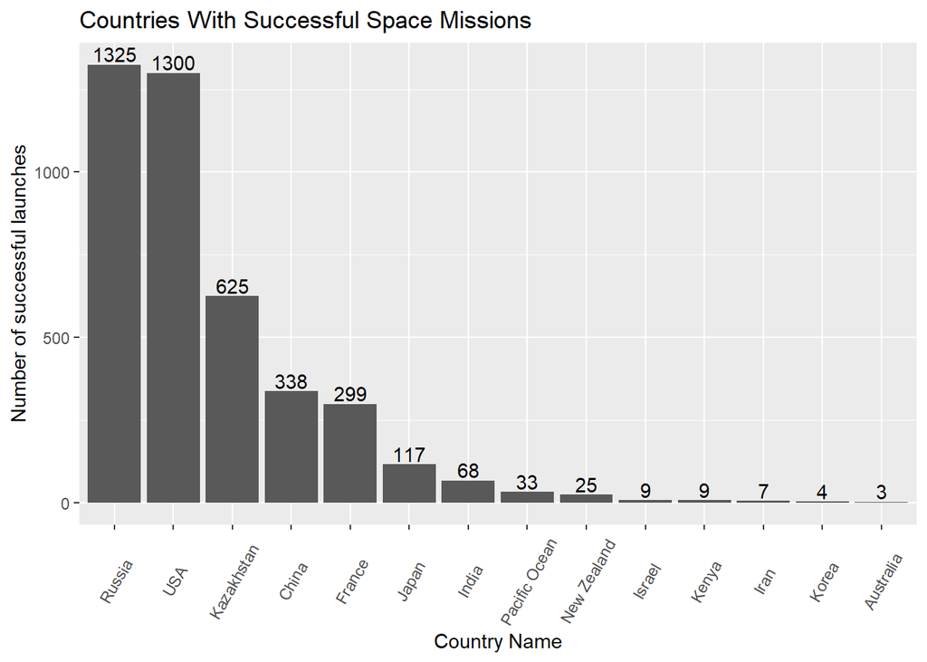

```r
space_missions_transformed %>%
  filter(mission_status == "Success") %>%
  group_by(country) %>%
  summarise(count = n()) %>%
  arrange(desc(count)) %>%
  ggplot(aes(x = fct_reorder(country, -count), y= count))+
  geom_bar(stat = "identity") +
  geom_text(aes(label = count), vjust = -0.2) +
  labs(title = "Countries With Successful Space Missions",
       x= "Country Name",
       y = "Number of successful launches") +
  theme(axis.text.x = element_text(angle = 60, vjust = 0.5, hjust = 0.5))
```

### Table of missions and their status per country

```r
table(space_missions_transformed$country,space_missions_transformed$mission_status)
```

```
##
##                 Failure Partial Failure Prelaunch Failure Success
##   Australia           3               0                 0       3
##   Brazil              2               0                 1       0
##   China              24               6                 0     338
##   France             14               5                 0     299
##   India               9               5                 0      68
##   Iran                9               0                 1       7
##   Israel              2               0                 0       9
##   Japan              10               3                 0     117
##   Kazakhstan         72              21                 1     625
##   Kenya               0               0                 0       9
##   Korea               6               0                 0       4
##   Mexico              1               3                 0       0
##   New Zealand         3               0                 0      25
##   Pacific Ocean       3               0                 0      33
##   Russia             64              30                 0    1325
##   USA               135              34                 1    1300
```

### Plotting mission status distribution over the total missions completed by top 5 countries

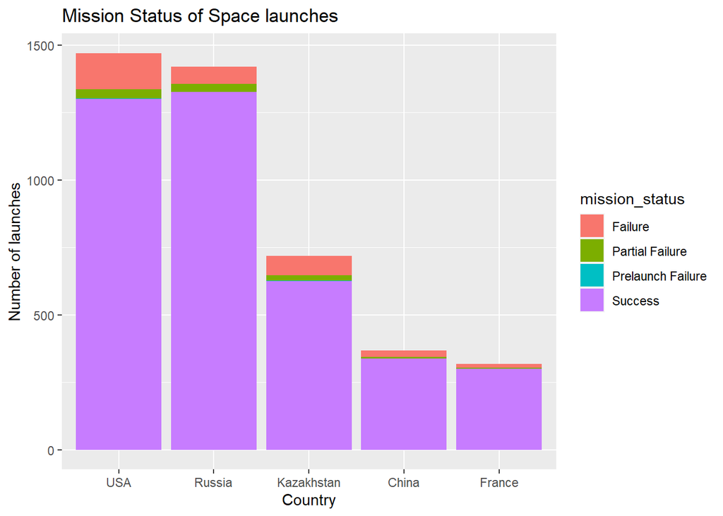

```r
space_missions_transformed %>%
  filter(country %in% c("USA", "Russia", "Kazakhstan", "China", "France")) %>%
  group_by(country,mission_status) %>%
  summarise(count = n())%>%
  slice_max(count, n = 5) %>%
  ggplot(aes(x = fct_reorder(country, -count), y = count, fill = mission_status)) +
  geom_bar(stat = "identity")+
  labs(title = "Mission Status of Space launches",
       x = "Country",
       y = "Number of launches")
```

## **How have rocket launches trended across time? Has mission success rate increased?**

### Plotting the total rocket launches from 1957- 2022.

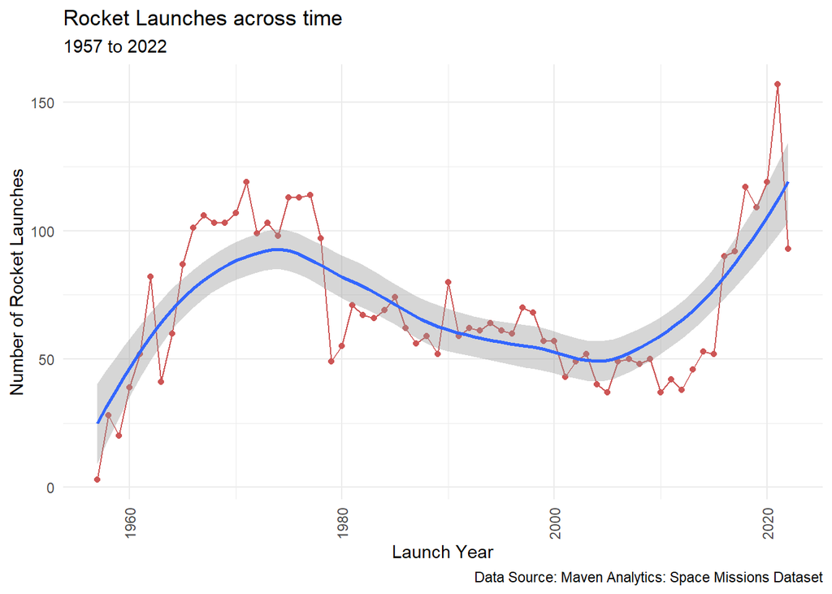

```r
space_missions_transformed %>%
  group_by(year) %>%
  summarise(count = n()) %>%
  ggplot(aes(x = year, y = count)) +
  geom_line(color = "indianred3") +
  geom_point(color = "indianred3")+
  geom_smooth() +
  labs(x = "Launch Year",
       y = "Number of Rocket Launches",
       title = "Rocket Launches across time",
       subtitle = "1957 to 2022") +
  theme_minimal() +
  theme(legend.position = "none",
        axis.text.x = element_text(angle = 90, vjust = 0.5, hjust = 0.5)) +
  labs(caption = "Data Source: Maven Analytics: Space Missions Dataset")
```

Here, We can see the trend in the number of space missions which increased from 1957-1975, decreased gradually from 1975-2005 and increased again from 2005 to 2022.

### Plotting successful launches of Russia and USA from 1957-2022.

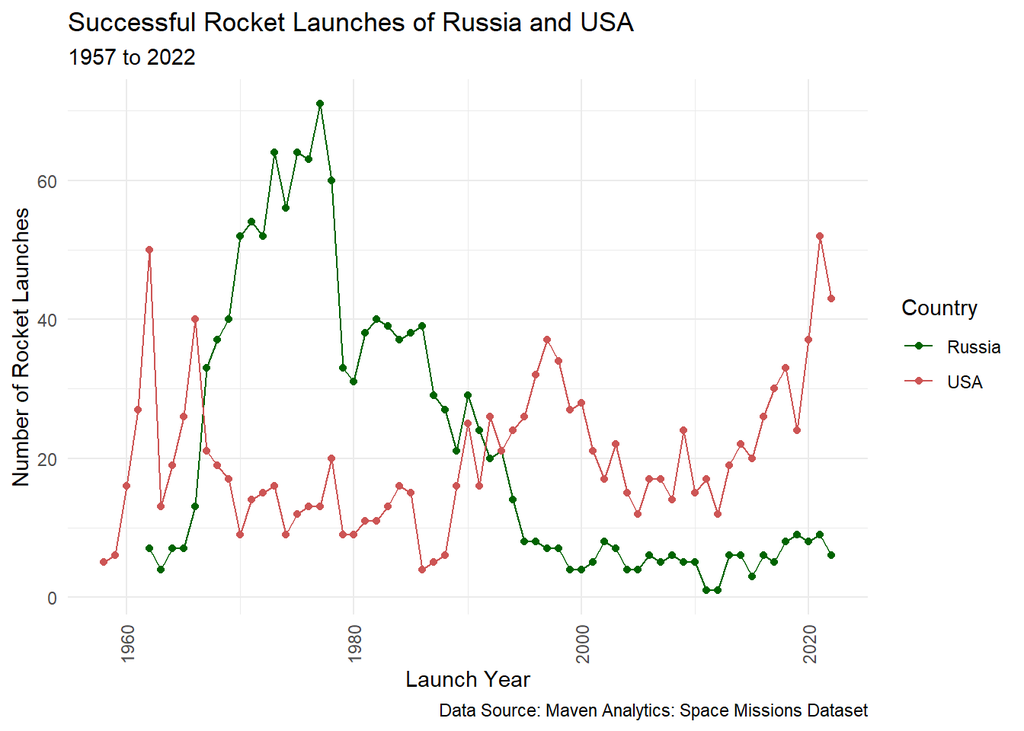

```r
space_missions_transformed %>%
  filter(mission_status == "Success" & country %in% c("Russia", "USA")) %>%
  group_by(country,year) %>%
  summarise(count = n()) %>%
  ggplot(aes(x = year, y = count, color = country)) +
  geom_line() +
  geom_point()+
  scale_color_manual(name = "Country",
                     values = c("darkgreen","indianred3"))+
  labs(x = "Launch Year",
       y = "Number of Rocket Launches",
       title = "Successful Rocket Launches of Russia and USA",
       subtitle = "1957 to 2022") +
  theme_minimal() +
  theme(legend.position = "right",
        axis.text.x = element_text(angle = 90, vjust = 0.5, hjust = 0.5)) +
  labs(caption = "Data Source: Maven Analytics: Space Missions Dataset")
```

Here we can see a pattern across time in the launches by both USA and Russia having relatively closer number of total successful launches.

We can see that Russia had higher number of successful launches than USA from 1968 to 1990 but the trend changes later from 1990 to 2022 where USA had a higher number of successful launches than Russia.

### Finding average mission success rate over time

#### First creating a new data frame to look at the number and status of mission launches by country and year

```r
mission_status <- space_missions_transformed %>%
  group_by(country, year, mission_status) %>%
  summarise(count = n())
```

#### Reshaping the above data from long to wide format

```r
mission_status <- mission_status %>%
  pivot_wider(names_from = mission_status,values_from = count)
```

```r
mission_status <- mission_status %>%
  replace_na(list("Success" = 0, "Failure" = 0, "Prelaunch Failure" = 0, "Partial Failure" = 0))
```

#### Changing the variable names for better readability

```r
colnames(mission_status)<- tolower(colnames(mission_status))

colnames(mission_status) <-  gsub("prelaunch failure", "prelaunch_failure",
       gsub("partial failure", "partial_failure",
            colnames(mission_status)))
```

#### Adding the column of success rate

```r
mission_status <- mission_status %>%
  mutate(success_rate = (success/sum(success, failure, prelaunch_failure, partial_failure)) * 100)
```

### Plot average success rate of the total missions from 1957-2022

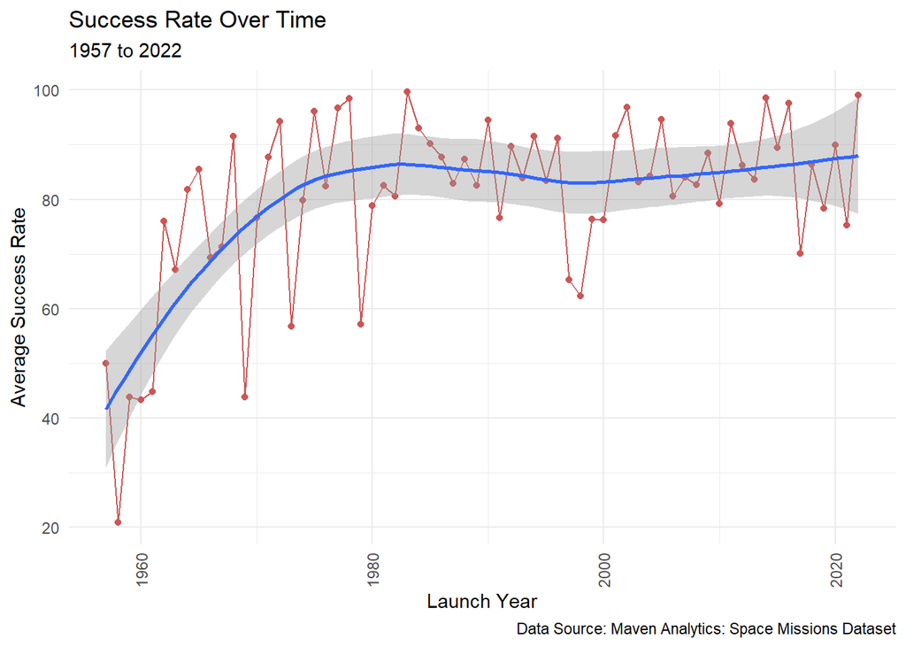

```r
mission_status %>%
  group_by(year) %>%
  summarise(mean_success_rate = mean(success_rate)) %>%
  ggplot(aes(x = year, y = mean_success_rate)) +
  geom_line(color = "indianred3")+
  geom_point(color = "indianred3")+
  geom_smooth() +
  labs(x = "Launch Year",
       y = "Average Success Rate",
       title = "Success Rate Over Time",
       subtitle = "1957 to 2022") +
  theme_minimal() +
  theme(legend.position = "none",
        axis.text.x = element_text(angle = 90, vjust = 0.5, hjust = 0.5)) +
  labs(caption = "Data Source: Maven Analytics: Space Missions Dataset")
```

We can see in the above graph that the average success rate of all the missions increases from 1957- 1980 but stays more or less the same from 1980- 2022.

## **Which rocket has been used for the most space missions? Is it still active?**

### Looking at the rockets used by all the countries for space missions

```r
space_missions_transformed %>%
  count(country, rocket, rocket_status, sort = TRUE) %>%
  arrange(desc(n))
```

[output not shown]

#### Creating a function to look at individual country rockets for automating the process

```r
rockets_by_country <- function(country_name){
  space_missions_transformed %>%
    filter(country == country_name) %>%
    count(rocket, rocket_status, sort = TRUE) %>%
    arrange(desc(n))
}
```

#### Looking at rockets used by top 5 countries for the missions

```r
rockets_by_country("Russia")

rockets_by_country("USA")

rockets_by_country("Kazakhstan")

rockets_by_country("China")

rockets_by_country("France")
```

[output not shown]

#### Creating a new data frame for the top 5 rockets used by each of the top 5 countries

```r
top_five_rockets <- space_missions_transformed %>%
  filter(country %in% c("Russia", "USA", "Kazakhstan", "China", "France")) %>%
  group_by(country, rocket) %>%
  summarise(launch_count = n()) %>%
  slice_max(launch_count, n = 5)
```

### Plotting top 5 rockets used for space missions by the above countries

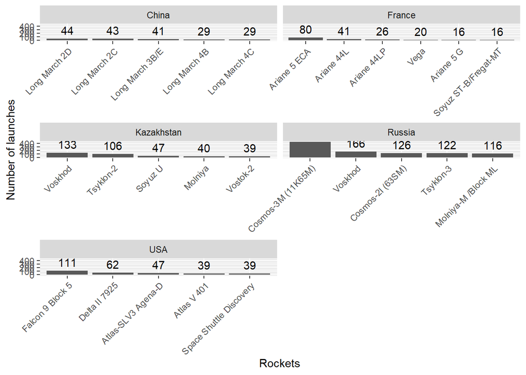

```r
space_missions_transformed %>%
  filter(country %in% c("Russia", "USA", "Kazakhstan", "China", "France")) %>%
  group_by(country, rocket) %>%
  summarise(cnt = n()) %>%
  slice_max(cnt, n = 5) %>%
  ggplot(aes(x = reorder(rocket, -cnt), y = cnt)) +
  geom_bar(stat = "identity") +
  geom_text(aes(label = cnt), vjust = -0.5) +
  facet_wrap(~country, ncol = 2, scales = "free_x") +
  theme(axis.text.x = element_text(angle = 45, hjust = 1))+
  labs(x = "Rockets", y = "Number of launches")
```

#### Creating a function to plot top 5 rockets of a country to automate the process

```r
plot_top_five_rockets <- function(country_name){
  space_missions_transformed %>%
    filter(country %in% c(country_name)) %>%
    group_by(country, rocket) %>%
    summarise(cnt = n()) %>%
    slice_max(cnt, n = 5) %>%
    ggplot(aes(x = reorder(rocket, -cnt), y = cnt)) +
    geom_bar(stat = "identity") +
    geom_text(aes(label = cnt), vjust = -0.5) +
    facet_wrap(~country, ncol = 2, scales = "free_x") +
    theme(axis.text.x = element_text(angle = 45, hjust = 1)) +
    labs(x = "Rockets", y = "Number of launches")
}
```

#### Plotting top 5 rockets used by each of the top 5 countries

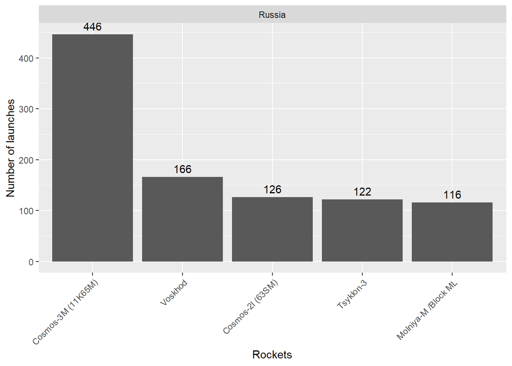

```r
plot_top_five_rockets("Russia")
```

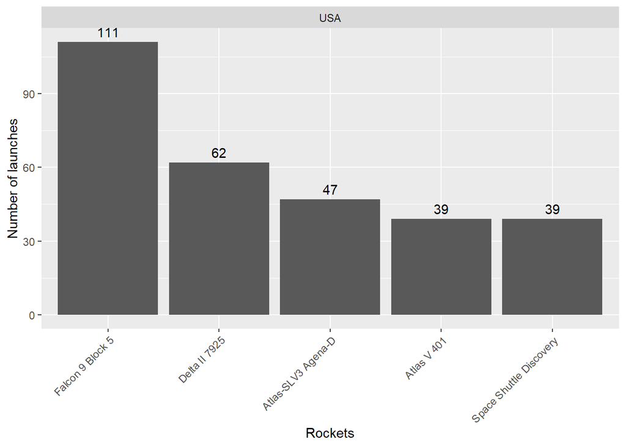

```r
plot_top_five_rockets("USA")
```

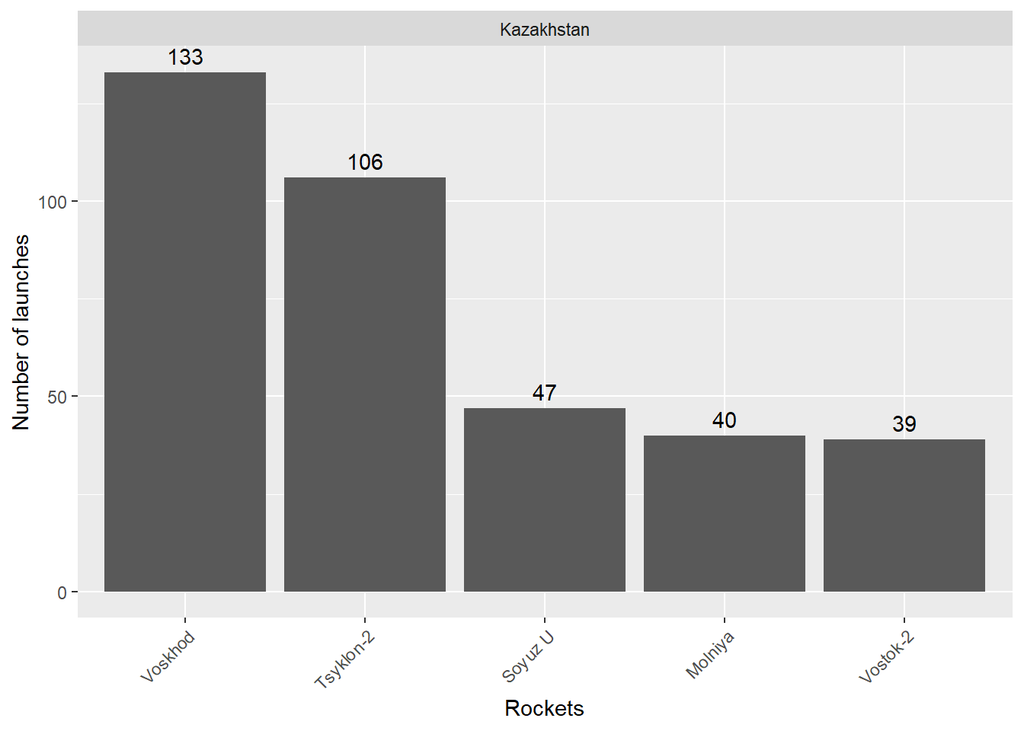

```r
plot_top_five_rockets("Kazakhstan")
```

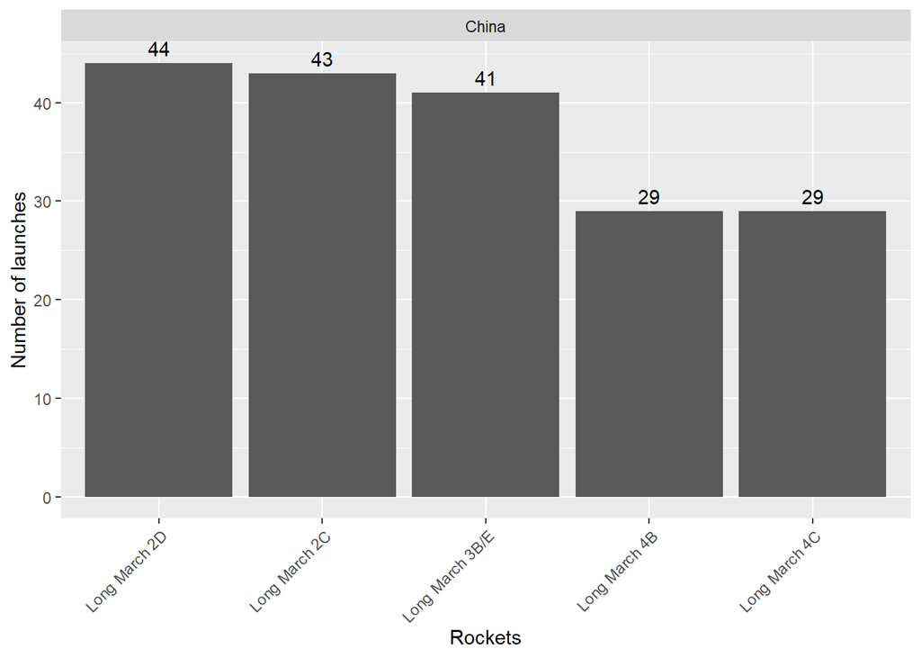

```r
plot_top_five_rockets("China")
```

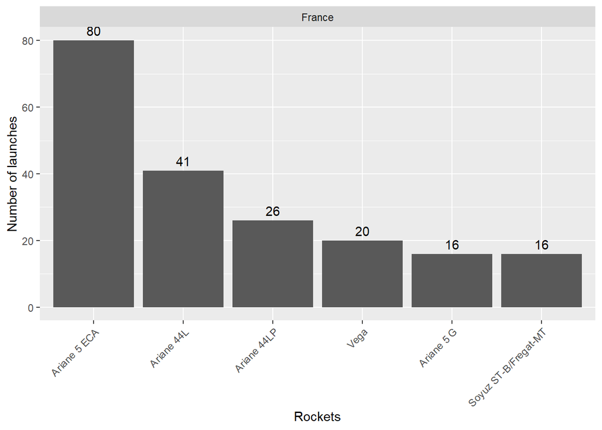

```r
plot_top_five_rockets("France")
```

### Determining status of the above rockets

#### Creating a function to plot rocket status of top 5 rockets of each of the countries

```r
plot_rocket_status <- function(country_name, rocket_name1, rocket_name2, rocket_name3,rocket_name4, rocket_name5){
  space_missions_transformed %>%
    filter(country == country_name & rocket %in% c(rocket_name1,rocket_name2, rocket_name3, rocket_name4, rocket_name5)) %>%
    group_by(rocket, rocket_status) %>%
    summarise(cnt = n()) %>%
    slice_max(cnt, n = 5) %>%
    ggplot(aes(x = reorder(rocket, -cnt), y = cnt, fill = rocket_status)) +
    geom_bar(stat = "identity") +
    scale_fill_manual(values = c("Active" = "darkgreen", "Retired" = "indianred3"))+
    geom_text(aes(label = cnt), vjust = -0.5) +
    theme(axis.text.x = element_text(angle = 45, hjust = 1))+
    labs(title =  "Top 5 Rocket Launches",
      subtitle = country_name,
      x = "Rockets",
      y = "Number of launches")
}
```

### Plotting top 5 Russian rockets and their status

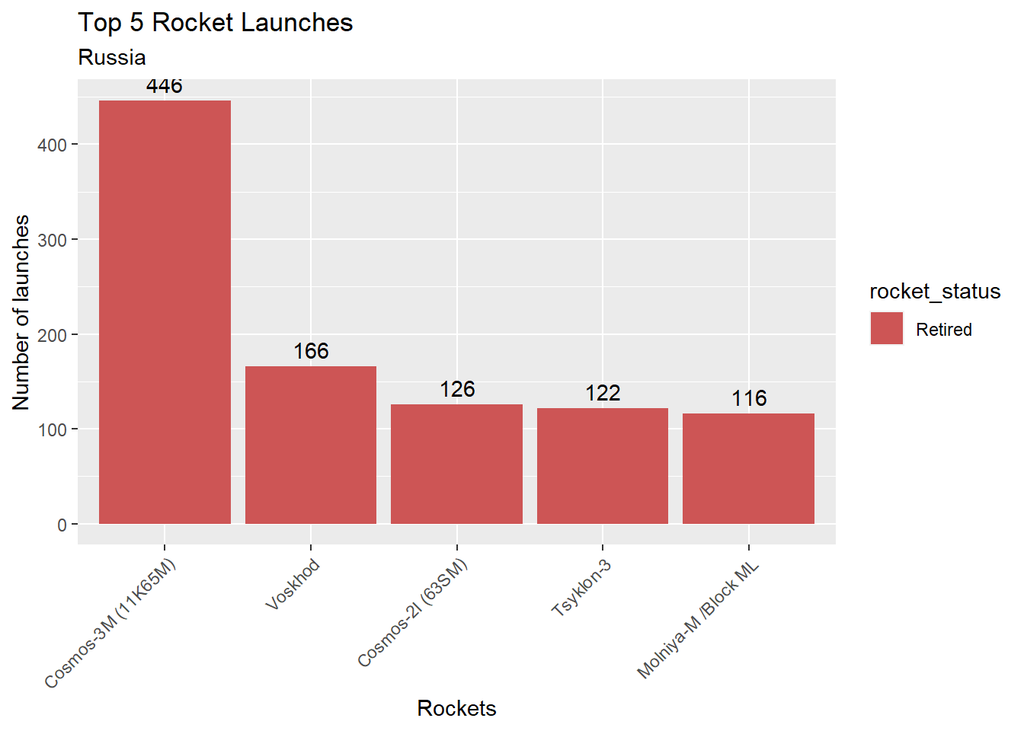

```r
plot_rocket_status("Russia","Cosmos-3M (11K65M)","Voskhod", "Cosmos-2I (63SM)", "Tsyklon-3", "Molniya-M /Block ML")
```

We can see that the rocket which is mostly used for most space missions is **Cosmos-3M (11K65M)** of Russia and it is **Retired**.

# Conclusion

1. Russia, USA, Kazakhstan, China and France are the top 5 countries which had the most successful space missions.
2. Russia and USA had relatively higher number of successful rocket launches than the other countries.
3. Russia had higher number of successful launches than USA from 1968 to 1990 but the trend changes later from 1990 to 2022 where USA had more successful launches than Russia.
4. There is an interesting trend in the total space missions from 1957- 2022 where total number of space missions increased and decreased over time as seen from the line chart.
   - Increased from 1957- 1975 : Mainly due to space race between USA and Soviet Union with rise in increased federal support and funding resulting in increased launches during that time frame. The race however ended in 1975 with the first cooperative launch of Apollo-Soyuz mission. [^1]
   - Decreased from 1975- 2005 : Possibly due increased cost of launching big satellites making space missions very costly. In addition to the increased cost, there was reduction in federal space funding to NASA after the space race which further slowed the space mission launches. [^2]
   - Increased from 2005- 2022 : Due to increased commercialization, technological advancements and building of smaller space crafts with missions becoming cost and fuel efficient. This helped more countries initiate their space missions.[^3]
5. The average mission success rate increased with the start of the launches in 1957 and until 1980 due to space race between Soviet Union and USA as described above but then has been steady in the later years.
6. The rocket used for the most space missions is Cosmos-3M (11K65M) of Russia and it is Retired.

##### **Thank you for taking the time to go through my analysis process and would appreciate any valuable feedback to improve my learning.**

### References

[Maven Analytics Dataset](https://mavenanalytics.io/data-playground?page=2&pageSize=5)

[^1]: Muir-Harmony, T. (2017, February 27). The Space Race and American Foreign Relations. Oxford Research Encyclopedia of American History. Retrieved 8 Aug. 2023, from https://oxfordre.com/americanhistory/view/10.1093/acrefore/9780199329175.001.0001/acrefore-9780199329175-e-274.
[^2]: Seck, N. (2012, August 26). Space race, on a budget, was not how Armstrong saw it. Phys.org. https://phys.org/news/2012-08-space-armstrong.html
[^3]: Louise Fox, L. S., West, D. M., Onder, H., & Katharine Kelley, J. B. (2023, June 24). How space exploration is fueling the Fourth Industrial Revolution. Brookings. https://www.brookings.edu/articles/how-space-exploration-is-fueling-the-fourth-industrial-revolution/